# Predicting oil and gas well abandonment

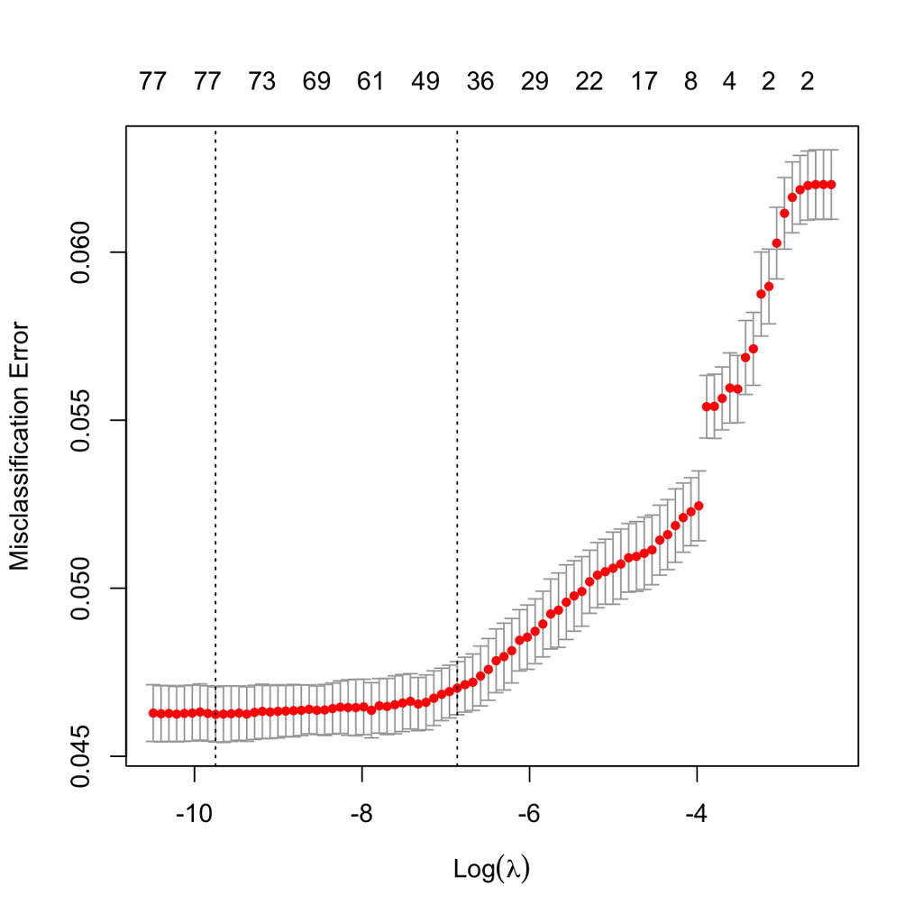

```r
# visualize lambda selection

set.seed(206)
m1lcv = cv.glmnet(Dx,Y,
                  family = 'binomial',
                  type.measure = "class",
                  nfolds=5)
plot(m1lcv)
```

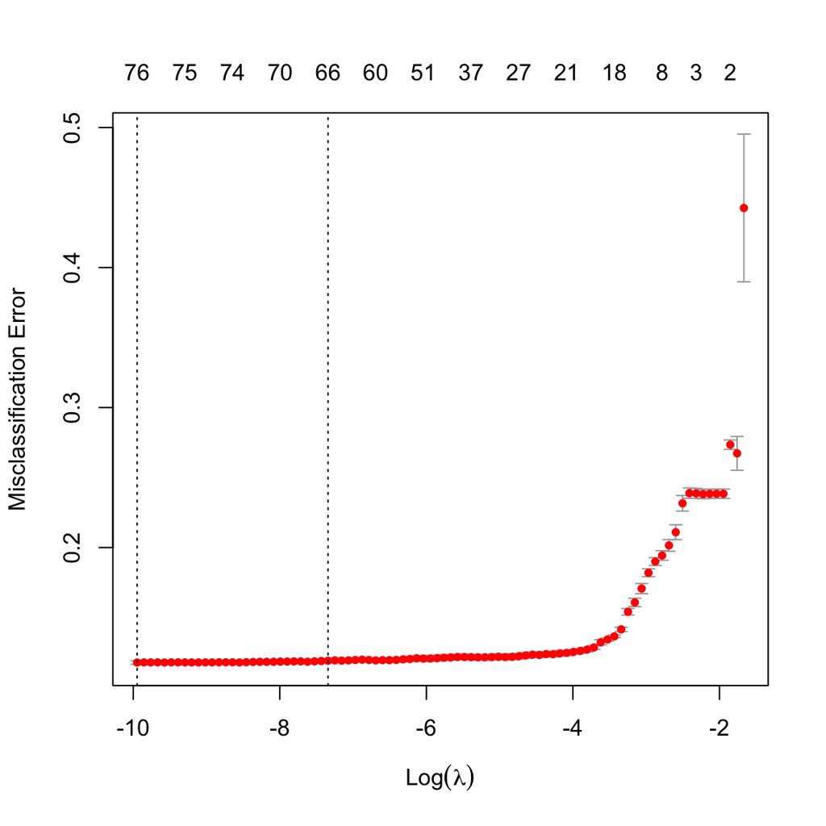

```r
set.seed(206)
m1lcvw = cv.glmnet(Dx,Y,
                  family = 'binomial',
                  type.measure = "class",
                  nfolds=5,
                  weights = weights)
plot(m1lcvw)
```

There’s definitely some learning going on, and correcting for the class imbalances helps (relatively speaking). Let’s check the features/odds ratios for the selected model. First, we'll look at the unweighted model. The second table describes the weighted model.

```r
tmp <- coef(m1lcv, s = "lambda.1se")
coefs <- data.frame(name = tmp@Dimnames[[1]][tmp@i + 1],
                   coefficient = tmp@x)
coefs$odds.ratio <- exp(coefs$coefficient)
coefs[,2:3] <- coefs[,2:3] %>% signif(digits = 5)

coefs %>% datatable(
  caption = 'Odds ratios >1 are predictive of orphan wells; odds ratios <1 are predictive of inactive wells')
```

|  | name | coefficient | odds.ratio |
| --- | --- | --- | --- |
| 1 | (Intercept) | 7.436 | 1696 |
| 2 | O.G.CodeG | 0.21295 | 1.2373 |
| 3 | District.Code02 | 0.7242 | 2.0631 |
| 4 | District.Code03 | 0.0063913 | 1.0064 |
| 5 | District.Code06 | 0.22478 | 1.252 |
| 6 | District.Code09 | -2.0464 | 0.1292 |
| 7 | District.Code7C | -1.1341 | 0.32171 |
| 8 | District.Code8A | -0.31341 | 0.73095 |
| 9 | Water.Land.CodeI | -2.1816 | 0.11286 |
| 10 | Water.Land.CodeL | -4.5276 | 0.010806 |

[output cut: 33 more lines]

```r
tmpw <- coef(m1lcvw, s = "lambda.1se")
coefsw <- data.frame(name = tmpw@Dimnames[[1]][tmpw@i + 1],
                   coefficient = tmpw@x)
coefsw$odds.ratio <- exp(coefsw$coefficient)
coefsw[,2:3] <- coefsw[,2:3] %>% signif(digits = 5)

coefsw %>% datatable(
  caption = 'Odds ratios >1 are predictive of orphan wells; odds ratios <1 are predictive of inactive wells. Classes were IPWed.')
```

|  | name | coefficient | odds.ratio |
| --- | --- | --- | --- |
| 1 | (Intercept) | 12.985 | 436030 |
| 2 | O.G.CodeG | 0.5389 | 1.7141 |
| 3 | District.Code02 | 0.54041 | 1.7167 |
| 4 | District.Code03 | 0.062029 | 1.064 |
| 5 | District.Code04 | -0.33679 | 0.71406 |
| 6 | District.Code05 | -0.19916 | 0.81942 |
| 7 | District.Code06 | 0.58244 | 1.7904 |
| 8 | District.Code08 | -0.080447 | 0.9227 |
| 9 | District.Code09 | -2.8093 | 0.060245 |
| 10 | District.Code10 | -0.55821 | 0.57223 |

[output cut: 57 more lines]

### Testing

Right. So there’s some compelling stuff here, but we need to see if the learning is real. Let’s drop 20 percent of our dataset, start over by re-running that cross-validation protocol, and test the model on the remaining data. We want to take a peek at the confusion matrices.

```r
set.seed(253)
Dxtri = sample(seq(length(Y)),round(length(Y)*.8),replace=FALSE)
m2lcvw = cv.glmnet(Dx[Dxtri,],Y[Dxtri],
                  family = 'binomial',
                  type.measure = "class",
                  nfolds=5,
                  weights = weights[Dxtri])
cmatTest <- confusion.glmnet(m2lcvw,
                             newx = Dx[-Dxtri,],
                             newy = Y[-Dxtri],
                             s = "lambda.1se")
cmatTest
```

```
##          True
## Predicted FALSE TRUE Total
##     FALSE 15734  142 15876
##     TRUE   2459 1058  3517
##     Total 18193 1200 19393
##
##  Percent Correct:  0.8659
```

Alright, so that’s a great sign. We’re looking at 88.2% sensitivity and 86.5% specificity on an out-of-sample test. We’re learning something! Let’s go back to the full model we trained above and check out the confusion matrix.

```r
cmat <- confusion.glmnet(m1lcvw,
                 newx = Dx,
                 newy = Y,
                 s = "lambda.1se")
cmat
```

```
##          True
## Predicted FALSE TRUE Total
##     FALSE 78680  606 79286
##     TRUE  12272 5407 17679
##     Total 90952 6013 96965
##
##  Percent Correct:  0.8672
```

Great! (I mean, terrifying, but you know what I mean.) By the way, for reference, here’s what happens if you don’t weight the classes:

```r
cmatnw <- confusion.glmnet(m1lcv,
                 newx = Dx,
                 newy = Y,
                 s = "lambda.1se")
cmatnw
```

```
##          True
## Predicted FALSE TRUE Total
##     FALSE 90441 4038 94479
##     TRUE    511 1975  2486
##     Total 90952 6013 96965
##
##  Percent Correct:  0.9531
```

(As hinted at previously, it pretty much just guesses 'inactive' all the time. Easy way to hit 95 percent overall accuracy... and like 30 percent sensitivity.) Anyway, let’s interrogate the model a bit more. Right now, it’s telling us that about 12272 inactive wells are more or less indistinguishable from wells on the state’s orphan well list. And yet… Texas doesn’t considers these wells to be abandoned. So what differentiates them from the abandoned wells?

```r
Dpred <- D
Dpred$predClass <- predict(m1lcvw,Dx,s="lambda.1se",type="class")
PRED_ABAN <- Dpred[Dpred$predClass==TRUE & Dpred$Is.Orphan.==FALSE,]
TRUE_ABAN <- Dpred[Dpred$Is.Orphan.==TRUE,]
TRUE_INACTIVE <- Dpred[Dpred$Is.Orphan.==FALSE,]

tests <- function(c1,c2){
  ks <- ks.test(c1,c2)
  m <- mood.test(c1,c2)
  v <- var.test(c1,c2)
  t <- t.test(c1,c2,var.equal=!v$p.value<.01)
  return(list(ks,m,t))
}

cat("\n----------------")
print("Age")
print("New Predicted Abandoned Wells:")
summary(PRED_ABAN$age)
print("Current Ground-Truth Abandoned Wells:")
summary(TRUE_ABAN$age)
print("Current Ground-Truth Inactive Wells:")
summary(TRUE_INACTIVE$age)
ageTests <- tests(PRED_ABAN$age,TRUE_ABAN$age)

cat("\n----------------")
print("Organization Age")
print("New Predicted Abandoned Wells:")
summary(PRED_ABAN$orgAge)
print("Current Ground-Truth Abandoned Wells:")
summary(TRUE_ABAN$orgAge)
print("Current Ground-Truth Inactive Wells:")
summary(TRUE_INACTIVE$orgAge)
orgAgeTests <- tests(PRED_ABAN$orgAge,TRUE_ABAN$orgAge)

cat("\n----------------")
print("Months Inactive")
print("New Predicted Abandoned Wells:")
summary(PRED_ABAN$inactiveTotalMonths)
print("Current Ground-Truth Abandoned Wells:")
summary(TRUE_ABAN$inactiveTotalMonths)
print("Current Ground-Truth Inactive Wells:")
summary(TRUE_INACTIVE$inactiveTotalMonths)
inactiveTotalMonthsTests <- tests(PRED_ABAN$inactiveTotalMonths,TRUE_ABAN$inactiveTotalMonths)

cat("\n----------------")
print("Violation Count")
print("New Predicted Abandoned Wells:")
summary(PRED_ABAN$violationCount)
print("Current Ground-Truth Abandoned Wells:")
summary(TRUE_ABAN$violationCount)
print("Current Ground-Truth Inactive Wells:")
summary(TRUE_INACTIVE$violationCount)
violationCountTests <- tests(PRED_ABAN$violationCount,TRUE_ABAN$violationCount)

cat("\n----------------")
print("Inspection Count")
print("New Predicted Abandoned Wells:")
summary(PRED_ABAN$inspectionCount)
print("Current Ground-Truth Abandoned Wells:")
summary(TRUE_ABAN$inspectionCount)
print("Current Ground-Truth Inactive Wells:")
summary(TRUE_INACTIVE$inspectionCount)
inspectionCountTests <- tests(PRED_ABAN$inspectionCount,TRUE_ABAN$inspectionCount)

cat("\n----------------")
print("Financial Assurance (Dollars)")
print("New Predicted Abandoned Wells:")
summary(PRED_ABAN$FA.Amount)
print("Current Ground-Truth Abandoned Wells:")
summary(TRUE_ABAN$FA.Amount)
print("Current Ground-Truth Inactive Wells:")
summary(TRUE_INACTIVE$FA.Amount)
FA.AmountTests <- tests(PRED_ABAN$FA.Amount,TRUE_ABAN$FA.Amount)

cat("\n----------------")
print("Well Depth")
print("New Predicted Abandoned Wells:")
summary(PRED_ABAN$API.Depth)
print("Current Ground-Truth Abandoned Wells:")
summary(TRUE_ABAN$API.Depth)
print("Current Ground-Truth Inactive Wells:")
summary(TRUE_INACTIVE$API.Depth)
API.DepthTests <- tests(PRED_ABAN$API.Depth,TRUE_ABAN$API.Depth)
```

```
##
## ----------------
## [1] "Age"
## [1] "New Predicted Abandoned Wells:"
##    Min. 1st Qu.  Median    Mean 3rd Qu.    Max.    NA's
##   1.168  23.696  36.852  35.230  41.982 120.166     206
## [1] "Current Ground-Truth Abandoned Wells:"
##    Min. 1st Qu.  Median    Mean 3rd Qu.    Max.    NA's
##   2.053  30.112  36.852  37.751  43.281  98.808     111
## [1] "Current Ground-Truth Inactive Wells:"
##    Min. 1st Qu.  Median    Mean 3rd Qu.    Max.    NA's
##   0.094  15.950  34.542  31.459  39.715 121.163    1290
##
## ----------------
## [1] "Organization Age"
## [1] "New Predicted Abandoned Wells:"
##    Min. 1st Qu.  Median    Mean 3rd Qu.    Max.    NA's
##  -0.003   2.909   6.975  10.808  15.942  43.437     111
## [1] "Current Ground-Truth Abandoned Wells:"
##    Min. 1st Qu.  Median    Mean 3rd Qu.    Max.    NA's
##   0.000   2.445   7.135  10.115  15.492  39.692      91
## [1] "Current Ground-Truth Inactive Wells:"
##    Min. 1st Qu.  Median    Mean 3rd Qu.    Max.    NA's
##  -0.003   4.821  12.025  15.151  22.890  43.516     279
##
## ----------------
## [1] "Months Inactive"
## [1] "New Predicted Abandoned Wells:"
##    Min. 1st Qu.  Median    Mean 3rd Qu.    Max.
##    14.0    43.0    76.0   111.1   179.0   337.0
## [1] "Current Ground-Truth Abandoned Wells:"
##    Min. 1st Qu.  Median    Mean 3rd Qu.    Max.
##    15.0    61.0   125.0   145.8   248.0   333.0
## [1] "Current Ground-Truth Inactive Wells:"
##    Min. 1st Qu.  Median    Mean 3rd Qu.    Max.
##    14.0    38.0    71.0   106.1   160.0   375.0
##
## ----------------
## [1] "Violation Count"
## [1] "New Predicted Abandoned Wells:"
```

[output cut: 29 more lines]

```
## [1] "Current Ground-Truth Inactive Wells:"
##    Min. 1st Qu.  Median    Mean 3rd Qu.    Max.
##       0  250000  250000  228736  250000 6850000
##
## ----------------
## [1] "Well Depth"
## [1] "New Predicted Abandoned Wells:"
##    Min. 1st Qu.  Median    Mean 3rd Qu.    Max.
##       0    2173    3625    4542    6394   19464
## [1] "Current Ground-Truth Abandoned Wells:"
##    Min. 1st Qu.  Median    Mean 3rd Qu.    Max.
##       0    2102    3521    4545    6200   22830
## [1] "Current Ground-Truth Inactive Wells:"
##    Min. 1st Qu.  Median    Mean 3rd Qu.    Max.
##       0    3310    5600    6084    8324   87600
```

Basically, it appears to be the case that predicted abandoned wells look quite similar to ground-truth abandoned wells… except when it comes to the amount of time they’ve been inactive. (There’s a median difference of about 49 months between the groups.) Our statistical tests aren’t extraordinarily helpful with large sample sizes like these – they’ll err on the side of significant – but take a look, for example, at the Kolmogorov-Smirnov test and Welch Two Sample t-test results for inactive time (p < 0 and 8.084594310^{-131}, respectively) and well depth (0.0229771 and 0.9616739). It’s clear that the former represent a meaningful set of differences.  
This difference would appear to suggest a temporal understanding of the model – that is, the predicted abandoned wells haven’t ended up on the state’s rolls because their operators aren’t **yet** delinquent (or the wells haven’t been inactive for **long enough** to be considered orphaned). But there’s reason for concern. If it quacks like a duck…  
To understand this time horizon, let’s just take a quick look at the past delinquency trajectories of operators with inactive wells.

```r
DOP <- dI[(dI$Well.Plugged == "N"), ]
DOP <- droplevels(DOP)
DOP <- DOP %>% select(-Well.Plugged)
DOP <- DOP %>% unique()
# DOP$Operator.Number <- as.factor(DOP$Operator.Number)
DOP$O.G.Code <- as.factor(DOP$O.G.Code)
DOP$District.Code <- as.factor(DOP$District.Code)
DOP$Water.Land.Code <- as.factor(DOP$Water.Land.Code)
DOP$Org.Type <- as.factor(DOP$Org.Type)
DOP$Mailing.Address.State <- as.factor(DOP$Mailing.Address.State)
DOP$FA.Option <- as.factor(DOP$FA.Option)
DOP$completionYear <- format(DOP$Original.Completion.Date, '%Y')
DOP$age <- round(as.numeric(difftime("2020-10-03",
                                     DOP$Original.Completion.Date,
                                     units = "weeks")
                            / 52) # in years
                 , 3)
DOP <- DOP %>% select(-Original.Completion.Date)
DOP$Last.P5.Filed.Date <- as.Date(DOP$Last.P5.Filed.Date, '%m/%d/%Y')
DOP$Initial.P5.Filed.Date <-
  as.Date(DOP$Initial.P5.Filed.Date, '%m/%d/%Y')
DOP$Expiration.Date <- as.Date(DOP$Expiration.Date, '%m/%d/%Y')
DOP$P5.Inactive.Date <- as.Date(DOP$P5.Inactive.Date, '%m/%d/%Y')
DOP$orgAge <- round(as.numeric(difftime(DOP$Last.P5.Filed.Date,
                                        DOP$Initial.P5.Filed.Date,
                                        units = "weeks")
                               / 52) # in years
                    , 3)
DOP$orgDelinquentTotalMonths <-
  round(as.numeric(difftime("2020-10-03",
                            DOP$Expiration.Date,
                            units = "weeks")
                   / 52) # in years
        , 3) * 12 # in months
DOP$Org.Type <-
  factor(DOP$Org.Type, levels = c(levels(DOP$Org.Type), "OTHER"))
DOP[grepl('OTHER', as.character(DOP$Org.Type)), 'Org.Type'] <- "OTHER"
DOP <- droplevels(DOP)
DOP$Mailing.Address.State <-
  factor(DOP$Mailing.Address.State, levels = c(levels(DOP$Mailing.Address.State), "OTHER"))
DOP$Mailing.Address.State <-
  factor(ifelse(DOP$Mailing.Address.State == "TX", "TX", "OTHER"))
summary(DOP$orgDelinquentTotalMonths)
```

```
##    Min. 1st Qu.  Median    Mean 3rd Qu.    Max.    NA's
## -14.988  -9.948  -5.928  -1.352  -2.952 449.652    1641
```

```r
summary(DOP[DOP$Extension.Status == "D", ]$orgDelinquentTotalMonths)
```

```
##    Min. 1st Qu.  Median    Mean 3rd Qu.    Max.    NA's
## -13.968  -9.948  -2.952  18.162  18.180 449.652     275
```

```r
summary(DOP[DOP$Extension.Status == "A", ]$orgDelinquentTotalMonths)
```

```
##    Min. 1st Qu.  Median    Mean 3rd Qu.    Max.    NA's
## -14.988  -9.948  -5.928  -6.835  -3.984 374.352    1366
```

```r
DOP$delinquent <- ifelse(DOP$Org.P5.Status == "DELINQUENT", 1, 0)
summary(DOP$delinquent)
```

```
##    Min. 1st Qu.  Median    Mean 3rd Qu.    Max.
##  0.0000  0.0000  0.0000  0.1164  0.0000  1.0000
```

```r
DOP$monthsTilDelinquent <-
  round(as.numeric(difftime(DOP$Expiration.Date,
                            DOP$Initial.P5.Filed.Date,
                            units = "weeks")
                   / 52) # in years
        , 3) * 12 # in months
DOP$monthsTilDelinquent <-
  ifelse(DOP$delinquent == 1,
         DOP$monthsTilDelinquent,
         round(as.numeric(difftime("2020-10-03",
                                   DOP$Initial.P5.Filed.Date,
                                   units = "weeks")
                          / 52)
               , 3) * 12)
DOP <-
  DOP %>% select(
    Operator.Number,
    County.Name,
    O.G.Code,
    District.Code,
    API.Depth,
    Cost.Calculation,
    inspectionCount,
    violationCount,
    Org.Type,
    Mailing.Address.State,
    FA.Option,
    FA.Amount,
    age,
    orgAge,
    normcommod.3,
    Unemployment.Rate.current,
    interest.rate.current,
    delinquent,
    monthsTilDelinquent
  )
DOP <- DOP %>% group_by(Operator.Number) %>% mutate(totalViolations = sum(violationCount))
DOP <- DOP %>% group_by(Operator.Number) %>% mutate(totalInspections = sum(inspectionCount))
DOP <- DOP %>% group_by(Operator.Number) %>% mutate(totalDepth = sum(API.Depth))
DOP <- DOP %>% group_by(Operator.Number) %>% mutate(totalCost = sum(Cost.Calculation))
DOP <- DOP %>% group_by(Operator.Number) %>% mutate(totalFA = sum(FA.Amount))
DOP <- DOP %>% group_by(Operator.Number) %>% mutate(medianDepth = median(API.Depth))
DOP <- DOP %>% group_by(Operator.Number) %>% mutate(medianCost = median(Cost.Calculation))
DOP <- DOP %>% group_by(Operator.Number) %>% mutate(medianAge = median(age))
DOP <- DOP %>% group_by(Operator.Number) %>% mutate(medianCommod3 = median(normcommod.3))
DOP <- DOP %>% group_by(Operator.Number) %>% mutate(medianUnemp = median(Unemployment.Rate.current))
DOP <- DOP %>% group_by(Operator.Number) %>% mutate(medianIR = median(interest.rate.current))

calculate_mode <- function(x) {
  uniqx <- unique(na.omit(x))
  uniqx[which.max(tabulate(match(x, uniqx)))]
}
DOP <- DOP %>% group_by(Operator.Number) %>% mutate(modeOG = calculate_mode(O.G.Code))
DOP <- DOP %>% group_by(Operator.Number) %>% mutate(modeCounty = calculate_mode(County.Name))
DOP <- DOP %>% group_by(Operator.Number) %>% mutate(modeDistrict = calculate_mode(District.Code))
DOP <- DOP %>% group_by(Operator.Number) %>% mutate(modeOT = calculate_mode(Org.Type))
DOP <- DOP %>% group_by(Operator.Number) %>% mutate(modeTX = calculate_mode(Mailing.Address.State))
DOP <- DOP %>% group_by(Operator.Number) %>% mutate(modeFAType = calculate_mode(FA.Option))
DOP <-
  DOP %>% select(
    Operator.Number,
    Org.Type,
    Mailing.Address.State,
    orgAge,
    delinquent,
    monthsTilDelinquent,
    totalViolations,
    totalInspections,
    totalCost,
    totalFA,
    medianDepth,
    medianAge,
    medianCommod3,
    medianUnemp,
    medianIR,
    modeOG,
    modeCounty,
    modeDistrict,
    modeFAType
  )
DOP <- DOP %>% ungroup() %>% select(-Operator.Number)
DOP <- unique(DOP)
n_distinct(dI$Operator.Number)
```

```
## [1] 3945
```

```r
nrow(DOP)
```

```
## [1] 3910
```

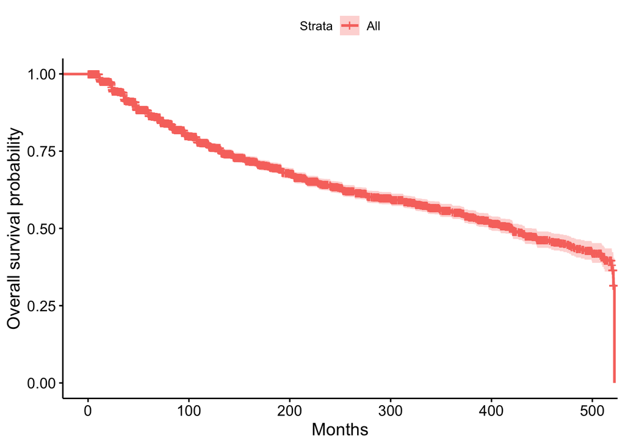

```r
# Kaplan-Meier plot
s1o <-
  survfit(Surv(monthsTilDelinquent, delinquent) ~ 1, data = DOP)
ggsurvplot(fit = s1o,
           xlab = "Months",
           ylab = "Overall survival probability")
```

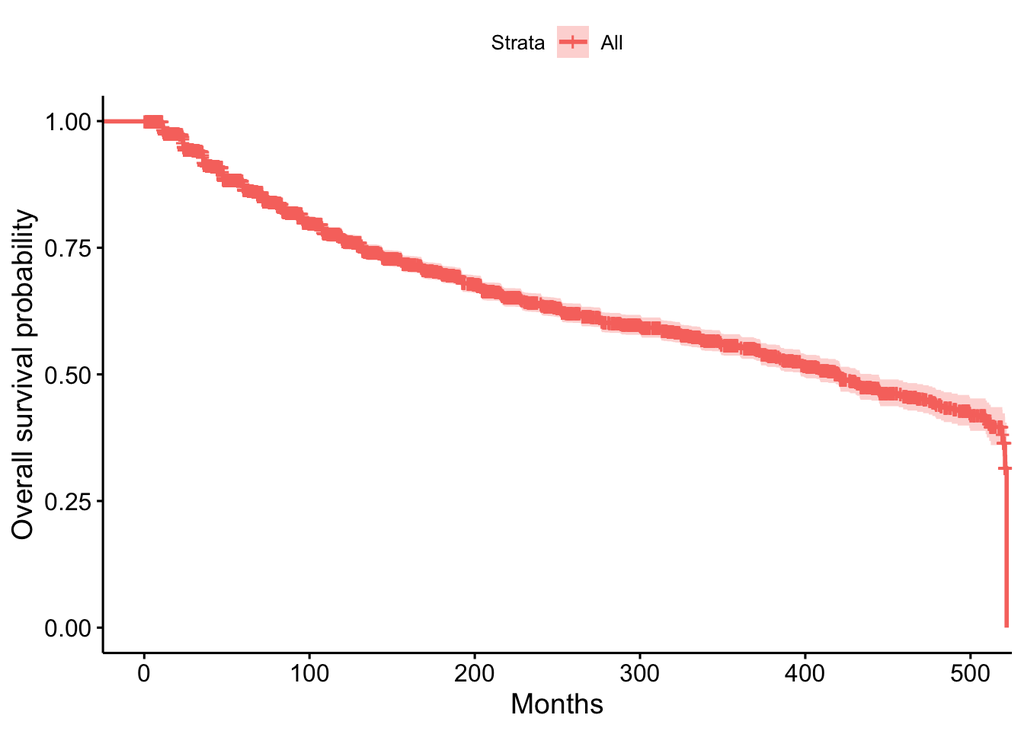

```r
# for reference, some K-M plots from the whole dataset
s1 <- survfit(Surv(inactiveTotalMonths, Is.Orphan.) ~ 1, data = D)
ggsurvplot(fit = s1o,
           xlab = "Months",
           ylab = "Overall survival probability")
```

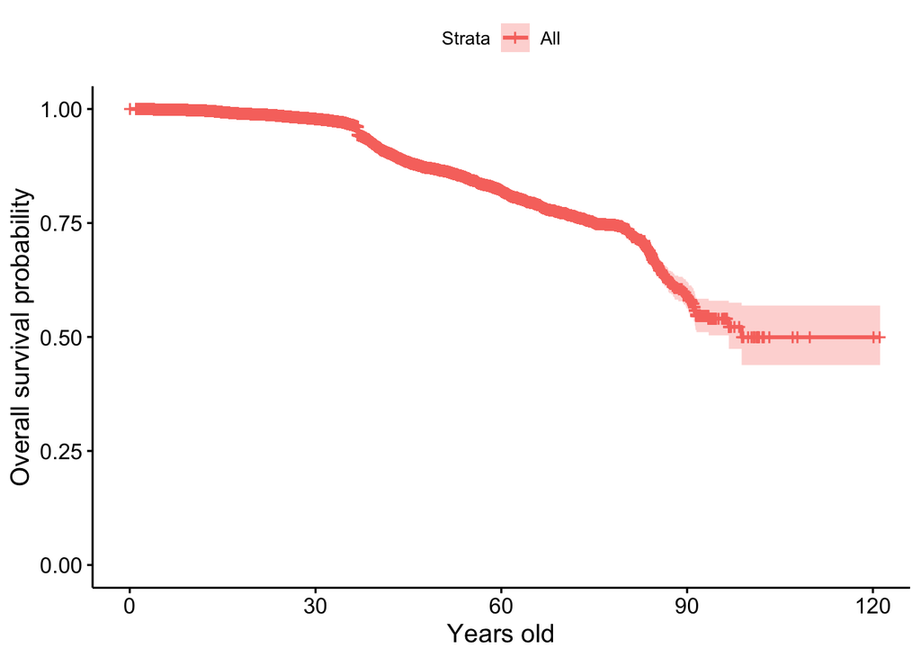

```r
s2 <- survfit(Surv(age, Is.Orphan.) ~ 1, data = D)
ggsurvplot(fit = s2,
           xlab = "Years old",
           ylab = "Overall survival probability")
```

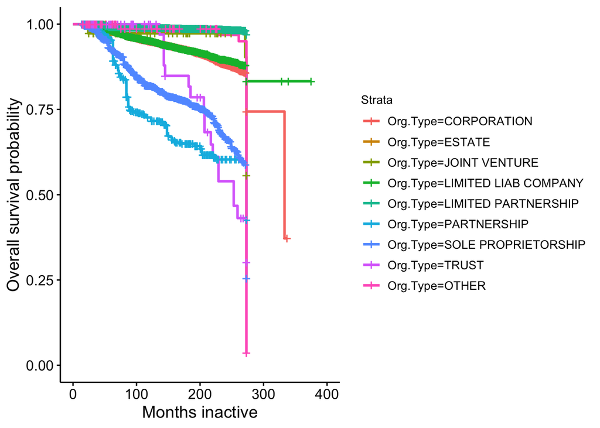

```r
s1OT <- survfit(Surv(inactiveTotalMonths, Is.Orphan.) ~ Org.Type, data = D)
ggsurvplot(fit = s1OT,
           xlab = "Months inactive",
           ylab = "Overall survival probability",
           legend = "right")
```

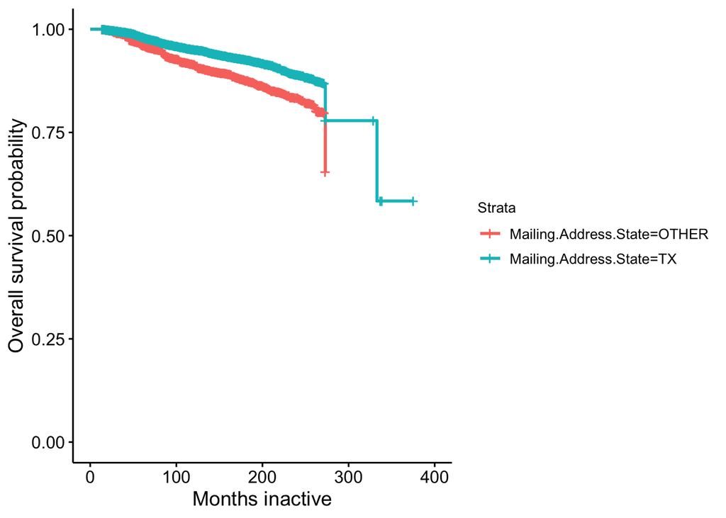

```r
s1OS <- survfit(Surv(inactiveTotalMonths, Is.Orphan.) ~ Mailing.Address.State, data = D)
ggsurvplot(fit = s1OS,
           xlab = "Months inactive",
           ylab = "Overall survival probability",
           legend = "right")
```

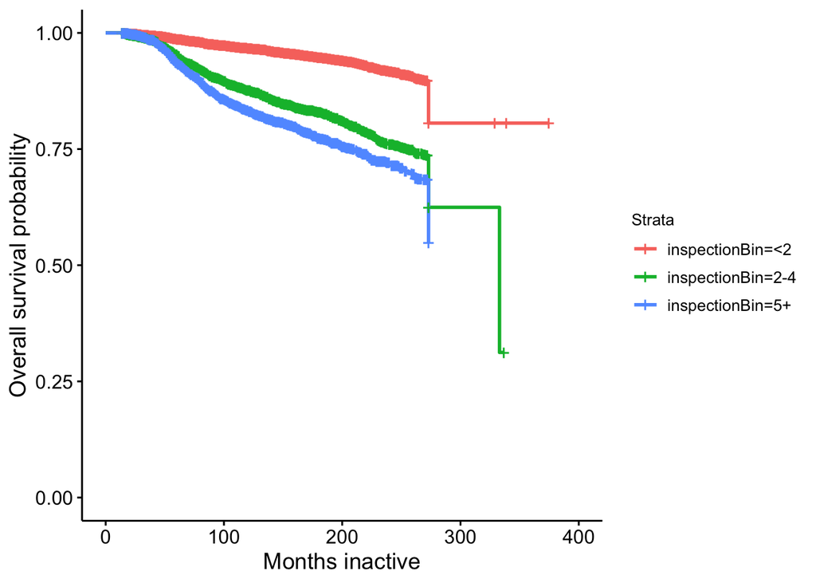

```r
b <- c(-Inf, 2, 5, Inf)
bnames <- c("<2", "2-4", "5+")
D$inspectionBin <- cut(D$inspectionCount, breaks = b, labels = bnames)

s1IC <- survfit(Surv(inactiveTotalMonths, Is.Orphan.) ~ inspectionBin, data = D)
ggsurvplot(fit = s1IC,
           xlab = "Months inactive",
           ylab = "Overall survival probability",
           legend = "right")
```

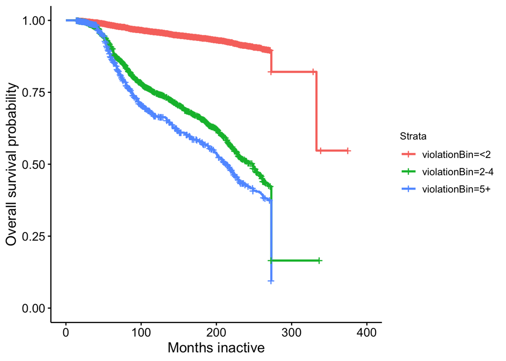

```r
b <- c(-Inf, 2, 5, Inf)
bnames <- c("<2", "2-4", "5+")
D$violationBin <- cut(D$violationCount, breaks = b, labels = bnames)

s1VC <- survfit(Surv(inactiveTotalMonths, Is.Orphan.) ~ violationBin, data = D)
ggsurvplot(fit = s1VC,
           xlab = "Months inactive",
           ylab = "Overall survival probability",
           legend = "right")
```

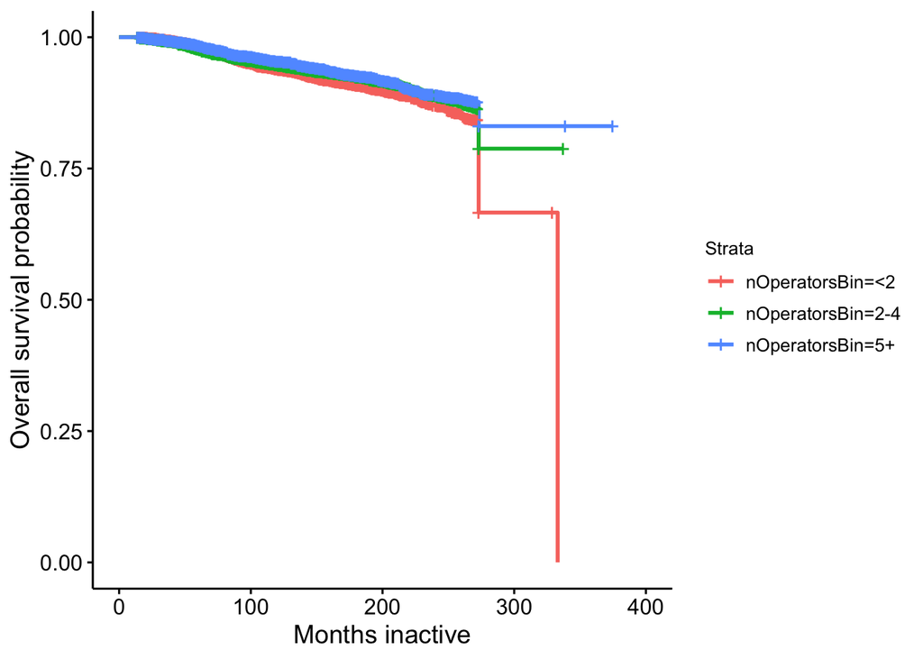

```r
b <- c(-Inf, 2, 5, Inf)
bnames <- c("<2", "2-4", "5+")
D$nOperatorsBin <- cut(D$nOperators, breaks = b, labels = bnames)

s1OC <- survfit(Surv(inactiveTotalMonths, Is.Orphan.) ~ nOperatorsBin, data = D)
ggsurvplot(fit = s1OC,
           xlab = "Months inactive",
           ylab = "Overall survival probability",
           legend = "right")
```

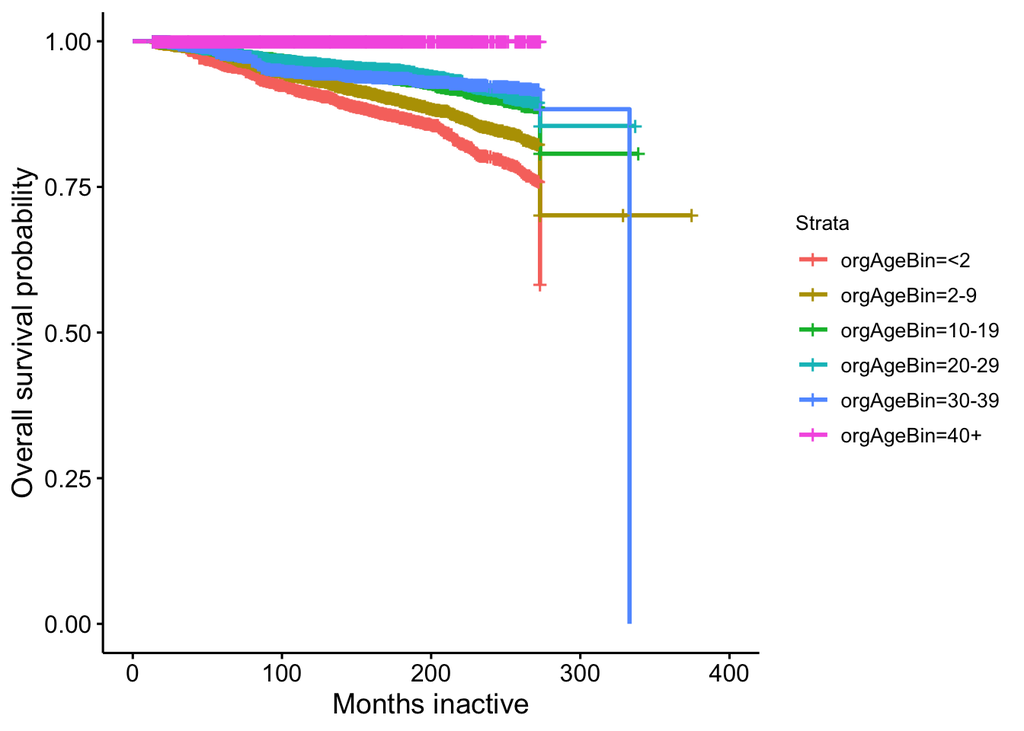

```r
b <- c(-Inf, 2, 10, 20, 30, 40, Inf)
bnames <- c("<2", "2-9", "10-19", "20-29", "30-39", "40+")
D$orgAgeBin <- cut(D$orgAge, breaks = b, labels = bnames)

s1OAB <- survfit(Surv(inactiveTotalMonths, Is.Orphan.) ~ orgAgeBin, data = D)
ggsurvplot(fit = s1OAB,
           xlab = "Months inactive",
           ylab = "Overall survival probability",
           legend = "right")
```

The important chart up there is the first one. Indeed, it looks like around 10 percent of operators with inactive wells wind up delinquent after about 50 months.

## New Mexico replication

Not much to add here! I’ve condensed some of the above steps into one long block below.

```r
macro <- read.csv('../data/macro.csv')
unemployment <- read.csv('../data/NM/county/unemployment.csv')
mappings <- read.csv('../data/NM/county/mappings.csv')
inspections <- read.csv('../data/NM/well/ic.csv',
                        stringsAsFactors = FALSE)
inactive <- read.csv('../data/NM/well/inactive.csv',
                     stringsAsFactors = FALSE)
operators <- read.csv('../data/NM/operator/operator.csv',
                     stringsAsFactors = FALSE)
bonding <- read.csv('../data/NM/operator/bonding.csv',
                     stringsAsFactors = FALSE)
abandoned <- read.csv('../data/NM/well/abandoned.csv',
                     stringsAsFactors = FALSE)
abandoned <- abandoned %>% select(API)

inactive$Last.Production <- as.Date(inactive$Last.Production, "%m/%d/%y")
inactive <- inactive[inactive$Last.Production <= "2019-06-01",] #2019-06-01 for TX mapping?

unemployment$Areaname <- unemployment$Areaname %>% trimws()
wup <- unemployment %>% filter(Areatype==4)
wup <- wup %>% select(Areaname,
                      Periodyear,
                      Laborforce,
                      Unemprate)
wup$Area <- as.factor(wup$Areaname)
wup <- wup[!duplicated(wup[c(1,2)]),]
wup <- wup %>% group_by(Areaname) %>% mutate(Laborforce.Change = (Laborforce - lag(Laborforce))/lag(Laborforce))

macro$date <- as.Date(macro$date, "%m/%d/%y")
macro$Year <- format(macro$date,"%Y") %>% as.integer()
macroAll <- wup %>% merge(macro,
                          by.x = "Periodyear",
                          by.y = "Year",
                          all.x = TRUE) # unique rows are county-month pairs
inactive <- inactive[inactive$API != "",]
inactive$Is.Orphan. <- ifelse(inactive$API %in% unique(abandoned$API), TRUE, FALSE)

apiList <- unique(inactive$API) # 4,467 entries
inspections <- inspections %>% subset(API %in% apiList) # 4,466 rows
inactive <- inactive %>% merge(inspections, by = "API")
inactive$inactiveTotalMonths <- as.integer((as.Date("2020-06-01") - inactive$Last.Production.x)/(365.25/12))
inactive$Original.Completion.Date <- as.Date(as.character(inactive$Spud.Date), #spud for NM
                                             "%Y-%m-%d")
dI <- inactive
dI$inspectionCount <- dI$InspectionsPerWell
dI$violationCount <- dI$IncidentsPerWell #i.e. actually incidents for NM
dI$violationCount2 <- dI$SpillsPerWell #i.e. actually spills for NM

dI <- dI %>% merge(operators,
                   by = "Ogrid",
                   all.x = TRUE)
dI <- dI %>% merge(bonding,
                   by = "API",
                   all.x = TRUE)

macroAll$Area <- gsub("Do\xf1a Ana County","Dona Ana County",macroAll$Area)
macroAll$Area <- tolower(macroAll$Area) %>% trimws() %>% as.factor()
macroAll$Area <- gsub(" county","",macroAll$Area)

mappings$county <- tolower(mappings$county) %>% trimws() %>% as.factor()
mappings$code <- frmt(mappings,"code",3)
dI$County <- substr(dI$API,4,6)
dI <- dI %>% merge(mappings,by.x="County",by.y = "code")
dI$County.Name <- tolower(dI$county) %>% trimws() %>% as.factor()

macroAll <- macroAll %>% merge(mappings,
                                by.x = "Area",
                                by.y = "county",
                                all.x = TRUE)
macroAll <- macroAll %>% select(-c(Areaname,code,Periodyear))

dI$inactiveDate <- dI$Last.Production.x
dI$inactiveDate3 <- dI$inactiveDate %m-% months(3)
dI$inactiveDate6 <- dI$inactiveDate %m-% months(6)
dI$inactiveDate12 <- dI$inactiveDate %m-% months(12)
dI$inactiveDate18 <- dI$inactiveDate %m-% months(18)
dI$inactiveDate24 <- dI$inactiveDate %m-% months(24)

dI$inactiveDate3p <- dI$inactiveDate %m+% months(3)
dI$inactiveDate6p <- dI$inactiveDate %m+% months(6)
dI$inactiveDate12p <- dI$inactiveDate %m+% months(12)

renames <- 7

dI <- dI %>% merge(macroAll,
                   by.x = c("inactiveDate","County.Name"),
                   by.y = c("date","Area"),
                   all.x = TRUE)
dI <- rn(dI,renames,"current")

dI <- dI %>% merge(macroAll,
                   by.x = c("inactiveDate3","County.Name"),
                   by.y = c("date","Area"),
                   all.x = TRUE)
dI <- rn(dI,renames,"3")

dI <- dI %>% merge(macroAll,
                   by.x = c("inactiveDate6","County.Name"),
                   by.y = c("date","Area"),
                   all.x = TRUE)
dI <- rn(dI,renames,"6")

dI <- dI %>% merge(macroAll,
                   by.x = c("inactiveDate12","County.Name"),
                   by.y = c("date","Area"),
                   all.x = TRUE)
dI <- rn(dI,renames,"12")

dI <- dI %>% merge(macroAll,
                   by.x = c("inactiveDate18","County.Name"),
                   by.y = c("date","Area"),
                   all.x = TRUE)
dI <- rn(dI,renames,"18")

dI <- dI %>% merge(macroAll,
                   by.x = c("inactiveDate24","County.Name"),
                   by.y = c("date","Area"),
                   all.x = TRUE)
dI <- rn(dI,renames,"24")

dI <- dI %>% merge(macroAll,
                   by.x = c("inactiveDate3p","County.Name"),
                   by.y = c("date","Area"),
                   all.x = TRUE)
dI <- rn(dI,renames,"3p")

dI <- dI %>% merge(macroAll,
                   by.x = c("inactiveDate6p","County.Name"),
                   by.y = c("date","Area"),
                   all.x = TRUE)
dI <- rn(dI,renames,"6p")

dI <- dI %>% merge(macroAll,
                   by.x = c("inactiveDate12p","County.Name"),
                   by.y = c("date","Area"),
                   all.x = TRUE)
dI <- rn(dI,renames,"12p")

# dI <- dI %>% mutate(totprod = scale(sumOil)+scale(sumGas))
dI <- dI %>% mutate(normcommod.current = ifelse(Type=="Gas",scale(ng.price.current),scale(wti.price.current)))
dI <- dI %>% mutate(normcommod.3 = ifelse(Type=="Gas",scale(ng.price.3),scale(wti.price.3)))
dI <- dI %>% mutate(normcommod.6 = ifelse(Type=="Gas",scale(ng.price.6),scale(wti.price.6)))
dI <- dI %>% mutate(normcommod.12 = ifelse(Type=="Gas",scale(ng.price.12),scale(wti.price.12)))
dI <- dI %>% mutate(normcommod.18 = ifelse(Type=="Gas",scale(ng.price.18),scale(wti.price.18)))
dI <- dI %>% mutate(normcommod.24 = ifelse(Type=="Gas",scale(ng.price.24),scale(wti.price.24)))
dI <- dI %>% mutate(normcommod.3p = ifelse(Type=="Gas",scale(ng.price.3p),scale(wti.price.3p)))
dI <- dI %>% mutate(normcommod.6p = ifelse(Type=="Gas",scale(ng.price.6p),scale(wti.price.6p)))
dI <- dI %>% mutate(normcommod.12p = ifelse(Type=="Gas",scale(ng.price.12p),scale(wti.price.12p)))
```

```r
dI <- droplevels(dI)
rownames(dI) <- NULL

dI <- dI %>% select(
                    API,
                    Ogrid.x,
                    County.Name,
                    Type,
                    District.x,
                    # LEASE,
                    # Field.Number,
                    OCD.Unit,
                    Lease.Type.x,
                    Mineral.Owner,
                    Measured.Depth,
                    Elevation,
                    Plugged.On,
                    # Extension.Status,
                    # Cost.Calculation,
                    # Well.Plugged,
                    Spud.Date,
                    Is.Orphan.,
                    inactiveTotalMonths,
                    inspectionCount,
                    violationCount,
                    violationCount2,
                    X5.9.Compliance.x,
                    Well.Count.x,
                    Inactive.Wells.x,
                    # Org.Type,
                    # Mailing.Address.State,
                    # Initial.P5.Filed.Date,
                    # Last.P5.Filed.Date,
                    # Expiration.Date,
                    # P5.Inactive.Date,
                    Required.Bond.Amount,
                    Bond.In.Place,
                    Bond.Required.Now,
                    Covered.By.Blanket.TA.Bond,
                    In.Violation,
                    # nOperators,
                    # sumOil,
                    # sumGas,
                    # totprod,
                    # Firms.current,
                    # Average.Weekly.Wage.current,
                    Unemprate.current,
                    Laborforce.current,
                    Laborforce.Change.current,
                    wti.price.current,
                    ng.price.current,
                    interest.rate.current,
                    interest.rate.change.current,
                    wti.price.3,
                    ng.price.3,
                    wti.price.6,
                    ng.price.6,
                    wti.price.12,
                    ng.price.12,
                    wti.price.18,
                    ng.price.18,
                    wti.price.24,
                    ng.price.24,
                    interest.rate.12,
                    interest.rate.change.12,
                    interest.rate.18,
                    interest.rate.change.18,
                    interest.rate.24,
                    interest.rate.change.24,
                    wti.price.3p,
                    ng.price.3p,
                    wti.price.6p,
                    ng.price.6p,
                    wti.price.12p,
                    ng.price.12p,
                    interest.rate.6p,
                    interest.rate.change.6p,
                    interest.rate.12p,
                    interest.rate.change.12p,
                    # Firms.12,
                    # Average.Weekly.Wage.12,
                    Unemprate.12,
                    Laborforce.12,
                    Laborforce.Change.12,
                    # Firms.24,
                    # Average.Weekly.Wage.24,
                    Unemprate.24,
                    Laborforce.24,
                    Laborforce.Change.24,
                    # Firms.12p,
                    # Average.Weekly.Wage.12p,
                    Unemprate.12p,
                    Laborforce.12p,
                    Laborforce.Change.12p,
                    normcommod.current,
                    normcommod.3,
                    normcommod.6,
                    normcommod.12,
                    normcommod.18,
                    normcommod.24,
                    normcommod.3p,
                    normcommod.6p,
                    normcommod.12p
                    )

dIs <- dI %>% select(
                    Is.Orphan.,
                    API,
                    Ogrid.x,
                    County.Name,
                    Type,
                    District.x,
                    # OCD.Unit,
                    Lease.Type.x,
                    Mineral.Owner,
                    Measured.Depth,
                    Elevation,
                    Spud.Date,
                    inactiveTotalMonths,
                    inspectionCount,
                    violationCount,
                    violationCount2,
                    X5.9.Compliance.x,
                    Well.Count.x,
                    Inactive.Wells.x,
                    Required.Bond.Amount,
                    Bond.In.Place,
                    Bond.Required.Now,
                    Covered.By.Blanket.TA.Bond,
                    In.Violation,
                    Unemprate.current,
                    Laborforce.current,
                    Laborforce.Change.current,
                    wti.price.current,
                    ng.price.current,
                    interest.rate.current,
                    interest.rate.change.current,
                    # wti.price.3,
                    # ng.price.3,
                    # wti.price.6,
                    # ng.price.6,
                    # wti.price.12,
                    # ng.price.12,
                    # wti.price.18,
                    # ng.price.18,
                    # wti.price.24,
                    # ng.price.24,
                    interest.rate.12,
                    interest.rate.change.12,
                    interest.rate.18,
                    interest.rate.change.18,
                    interest.rate.24,
                    interest.rate.change.24,
                    # wti.price.3p,
                    # ng.price.3p,
                    # wti.price.6p,
                    # ng.price.6p,
                    # wti.price.12p,
                    # ng.price.12p,
                    interest.rate.6p,
                    interest.rate.change.6p,
                    interest.rate.12p,
                    interest.rate.change.12p,
                    Unemprate.12,
                    Laborforce.12,
                    Laborforce.Change.12,
                    Unemprate.24,
                    Laborforce.24,
                    Laborforce.Change.24,
                    Unemprate.12p,
                    Laborforce.12p,
                    Laborforce.Change.12p,
                    normcommod.current,
                    normcommod.3,
                    normcommod.6,
                    normcommod.12,
                    normcommod.18,
                    normcommod.24,
                    normcommod.3p,
                    normcommod.6p,
                    normcommod.12p
                    )
```

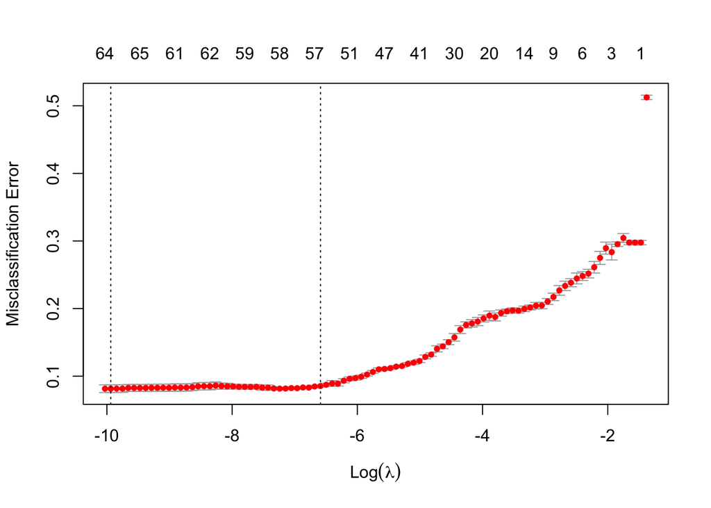

```r
TX <- D # stash TX here
D <- dIs %>% unique()

# D$Operator.Number <- as.factor(D$Operator.Number)
D$Type <- as.factor(D$Type)
D$Ogrid.x <- as.factor(D$Ogrid.x)
D$District.x <- as.factor(D$District.x)
D$Lease.Type.x <- as.factor(D$Lease.Type.x)
D$Mineral.Owner <- as.factor(D$Mineral.Owner)
D$X5.9.Compliance.x <- as.factor(D$X5.9.Compliance.x)
D$Bond.Required.Now <- as.factor(D$Bond.Required.Now)
D$Covered.By.Blanket.TA.Bond <- as.factor(D$Covered.By.Blanket.TA.Bond)
D$In.Violation <- as.factor(D$In.Violation)

D$Required.Bond.Amount <- as.numeric(D$Required.Bond.Amount)

D$completionYear <- format(as.Date(D$Spud.Date),'%Y')
D$age <- round(as.numeric(difftime("2020-06-01",
                                   as.Date(D$Spud.Date),
                                   units="weeks")/52) # in years
               ,3)
D <- D %>% select(-Spud.Date)
D <- droplevels(D)

Dx <- D %>% select(-c(Is.Orphan.,
                      completionYear,
                      API,
                      Ogrid.x,
                      Bond.Required.Now,
                      Covered.By.Blanket.TA.Bond,
                      In.Violation,
                      County.Name
                      # inactiveTotalMonths,
                      # LEASE,
                      # Field.Number,
                      ))
Dxn <- Dx %>% select_if(is.numeric)
Dxn <- replace(Dxn, TRUE, lapply(Dxn, NA2mean))
Dxf <- Dx %>% select_if(is.factor)
Dx <- cbind(Dxf,Dxn)
Dx <- model.matrix(~.-1,Dx)

# IPW classes
Y <- D$Is.Orphan.
f0 <- rep(1 - sum(Y == 0) / length(Y), sum(Y == 0))
f1 <- rep(1 - sum(Y == 1) / length(Y), sum(Y == 1))
weights <- numeric(length(Y))
weights[Y == 0] <- f0
weights[Y == 1] <- f1

# visualize lambda selection
set.seed(206)
m1lcvwnm = cv.glmnet(Dx,Y,
                  family = 'binomial',
                  type.measure = "class",
                  nfolds=5,
                  weights = weights)
plot(m1lcvwnm)
```

```r
set.seed(763)
Dxtri = sample(seq(length(Y)),round(length(Y)*.8),replace=FALSE)
m2lcvwnm = cv.glmnet(Dx[Dxtri,],Y[Dxtri],
                  family = 'binomial',
                  type.measure = "class",
                  nfolds=5,
                  weights = weights[Dxtri])
confusion.glmnet(m2lcvwnm,
                 newx = Dx[-Dxtri,],
                 newy = Y[-Dxtri],
                 s = "lambda.1se")
```

```
##          True
## Predicted FALSE TRUE Total
##     FALSE   693    8   701
##     TRUE     74  118   192
##     Total   767  126   893
##
##  Percent Correct:  0.9082
```

```r
confusion.glmnet(m1lcvwnm,
                 newx = Dx,
                 newy = Y,
                 s = "lambda.1se")
```

```
##          True
## Predicted FALSE TRUE Total
##     FALSE  3414   26  3440
##     TRUE    421  605  1026
##     Total  3835  631  4466
##
##  Percent Correct:  0.8999
```

```r
tmpw <- coef(m1lcvwnm, s = "lambda.1se")
coefsw <- data.frame(name = tmpw@Dimnames[[1]][tmpw@i + 1],
                   coefficient = tmpw@x)
coefsw$odds.ratio <- exp(coefsw$coefficient)
coefsw[,2:3] <- coefsw[,2:3] %>% signif(digits = 5)

coefsw %>% datatable(
  caption = 'Odds ratios >1 are predictive of orphan wells; odds ratios <1 are predictive of inactive wells. Classes were IPWed.')
```

|  | name | coefficient | odds.ratio |
| --- | --- | --- | --- |
| 1 | (Intercept) | -5.0702 | 0.0062813 |
| 2 | TypeInjection | -0.084994 | 0.91852 |
| 3 | TypeOil | 0.3185 | 1.3751 |
| 4 | TypeSalt Water Disposal | 0.53916 | 1.7146 |
| 5 | District.x2 | 0.32146 | 1.3791 |
| 6 | District.x3 | -0.59567 | 0.55119 |
| 7 | Lease.Type.xI | -4.1448 | 0.015847 |
| 8 | Lease.Type.xJ | 3.8831 | 48.576 |
| 9 | Lease.Type.xN | -3.9014 | 0.020214 |
| 10 | Lease.Type.xP | -0.30487 | 0.73722 |

[output cut: 48 more lines]

## Addendum

And a quick figure to examine the effect of oil prices on aggregate annual abandonment rates:

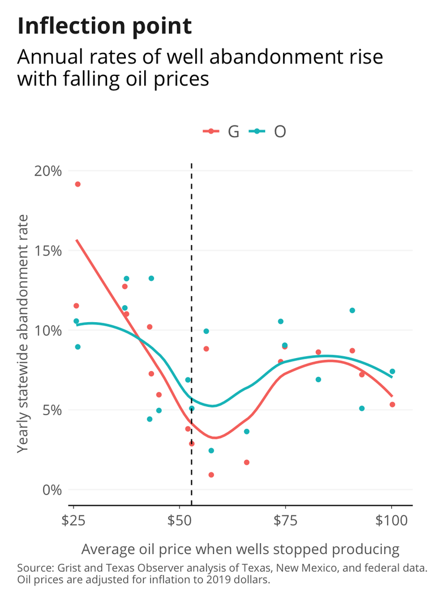

```r
library(segmented)
setwd("~/Developer/gristy/abandoned-wells/src")
style <- "grist"
source("gristify.R")

macro <- read.csv('../data/macro.csv')
macro$date <- as.Date(macro$date, "%m/%d/%y")
macro$Year <- format(macro$date,"%Y") %>% as.integer()

cpi <- read.csv('../data/CPI-to-1999.csv') %>% dplyr::select(ipums_match,cpi)
cpi$ipums_match <- as.character(cpi$ipums_match)
macro <- macro %>% merge(cpi,
                   by.x = "Year",
                   by.y = "ipums_match")
macro$wti.price <- macro$wti.price * macro$cpi * 1.535 # i.e. to 2019 dollars (use 1.507 for 2018)

tx <- read.csv('../data/TX/well/IWAR_20201003.csv',
                     stringsAsFactors = FALSE)
tx$inactiveTotalMonths <- (tx$Current.Inactive.Years * 12) +
  tx$Current.Inactive.Months
tx$inactiveDate <- as.Date("2020/10/01") %m-% months(tx$inactiveTotalMonths)
tx <- tx %>% select(O.G.Code,inactiveDate,Is.Orphan.) %>% mutate(state="TX")
names(tx) <- c("Type","inactiveDate","Is.Orphan.","state")

nm <- read.csv('../data/NM/well/inactive.csv',
                     stringsAsFactors = FALSE)
nm$Last.Production <- as.Date(nm$Last.Production, "%m/%d/%y")
nm <- nm[nm$Last.Production <= "2019-06-01",]
nm <- nm[nm$API != "",]
nm$Is.Orphan. <- ifelse(nm$API %in% unique(abandoned$API), TRUE, FALSE)
nm$inactiveTotalMonths <- as.integer((as.Date("2020-06-01") -
                                        nm$Last.Production)/(365.25/12))
nm$inactiveDate <- as.Date("2020/06/01") %m-% months(nm$inactiveTotalMonths)
nm <- nm %>% select(Well.Type,inactiveDate,Is.Orphan.) %>% mutate(state="NM")
names(nm) <- c("Type","inactiveDate","Is.Orphan.","state")

txnm <- rbind(tx,nm)
txnm <- txnm %>% filter(Type %in% c("O","G"))
txnm <- txnm %>% merge(macro,
                       by.x = c("inactiveDate"),
                       by.y = c("date"),
                       all.x = TRUE)
txnm <- txnm %>% filter(inactiveDate >= as.Date("1998-01-01"))

txnm$inactiveYear <- format(txnm$inactiveDate,'%Y')
txnm <- txnm %>%
  group_by(inactiveYear) %>%
  mutate(meanWTI = mean(wti.price,na.rm=TRUE)) %>%
  ungroup()
txnm <- txnm %>%
  group_by(inactiveYear,
           Type
           ) %>%
  mutate(iO = mean(Is.Orphan.,na.rm=TRUE)) %>%
  ungroup()

prices <- txnm %>% select(meanWTI,
                          iO,
                          inactiveYear,
                          Type
                          ) %>% unique()
prices <- prices %>% filter(iO <= 0.4)

my.seg <- segmented(lm(iO ~ meanWTI, data = prices),
                    seg.Z = ~ meanWTI,
                    psi = 75)

title <- "Inflection point"
subtitle <- "Annual rates of well abandonment rise \nwith falling oil prices"
caption <- "Source: Grist and Texas Observer analysis of Texas, New Mexico, and federal data. \nOil prices are adjusted for inflation to 2019 dollars."
xLab <- "Average oil price when wells stopped producing"
yLab <- "Yearly statewide abandonment rate"

yAxisBreaks <- seq(0, .2, by=.05) #seq(-10, 30, by=5)
yAxisLabels <- paste0(yAxisBreaks*100,"%")
yAxisLimits <- c(-.01,max(yAxisBreaks)* 1.03)

xAxisBreaks <- seq(25, 100, by = 25)
xAxisLabels <- paste0("$",xAxisBreaks)
xAxisLimits <- c(min(xAxisBreaks)*.95,max(xAxisBreaks)* 1.05)

ggplot(prices,
       aes(x = meanWTI,
           y = iO,
           color = Type
           )) +
  geom_point() +
  geom_smooth(method = "loess", se=FALSE) +
  scale_x_continuous(labels=xAxisLabels, expand = c(0, 0), breaks=xAxisBreaks, limits=xAxisLimits) +
  scale_y_continuous(labels=yAxisLabels, expand = c(0, 0), breaks=yAxisBreaks, limits=yAxisLimits) +

  labs(x=xLab, y=yLab, title=title, subtitle=subtitle,
       caption=caption) +
  geom_vline(xintercept = my.seg$psi[2],linetype="dashed") +

  theme_minimal() + gristify()
```